# Data Pre-processing Using R

Hui Lin

Monday, October 26, 2015

There are a number of reasons a predictive model falls. One of them is inadequate data pre-processing. In this blog post, I am going to outline the common data pre-processing approaches and discuss when to use them.

## **Centering and Scaling**

It is the most straightforward data transformation. It centers and scales a variable to mean 0 and standard deviation 1. It ensures that the criterion for finding linear combinations of the predictors is based on how much variation they explain and therefore improves the numerical stability. Models involving finding linear combinations of the predictors to explain response/predictors variation need data centering and scaling, such as PCA and PLS. You can easily writing code yourself to conduct this transformation. Or the function `preProcess()` in package `caret` can apply this transformation to a set of predictors.

```r
library(caret)
head(cars)
```

```
##   speed dist
## 1     4    2
## 2     4   10
## 3     7    4
## 4     7   22
## 5     8   16
## 6     9   10
```

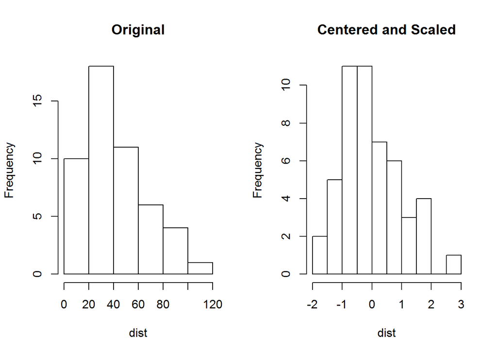

```r
trans<-preProcess(cars,method=c("center","scale"))
transformed<-predict(trans,cars)
par(mfrow=c(1,2))
hist(cars$dist,main="Original",xlab="dist")
hist(transformed$dist,main="Centered and Scaled",xlab="dist")
```